# Model exploration of AT–CTI Disequilibrium

- Show All Code
- Hide All Code

# 1 Model formulation

## 1.1 Motivation: the analogue of the Lotka–Volterra model

The classical Lotka–Volterra predator–prey model describes reciprocal interactions: prey abundance affects predator growth, while predators affect prey loss. Here, the ecological question is similar but different. Annual temperature ($x$) may influence the community temperature index ($\mu$), but $\mu$ does not feed back on annual temperature.

The causal direction is therefore

$$x_t \longrightarrow \mu_{t+1},$$

with no reciprocal term

$$\mu_t \not\longrightarrow x_{t+1}.$$
It is a one-way, discrete-time dynamic system that borrows the idea of coupling two state variables while allowing only one directional interaction.

## 1.2 Discrete-time model

Let $x_t$ and $\mu_t$ denote annual temperature and the community temperature index at time $t$. Ignoring the error terms temporarily, define

$$x_{t+1}=x_t+ax_t=(1+a)x_t,$$

and

$$\mu_{t+1}=\mu_t+b\mu_t+cx_t
=(1+b)\mu_t+cx_t.$$

In matrix form,

$$\begin{pmatrix}
x_{t+1}\\
\mu_{t+1}
\end{pmatrix}
=
\begin{pmatrix}
1+a & 0\\
c & 1+b
\end{pmatrix}
\begin{pmatrix}
x_t\\
\mu_t
\end{pmatrix}.$$

The zero in the upper-right corner encodes the one-way assumption: CTI does not affect subsequent AT.

## 1.3 Interpretation of the three parameters

### 1.3.1 Parameter $a$: temporal change in AT

$$x_{t+1}=(1+a)x_t.$$

- $a>0$: AT increases multiplicatively through time.
- $a=0$: AT remains constant.
- $a<0$: AT decreases multiplicatively.

For example, $a=0.02$ means that AT is multiplied by $1.02$ at each time step.

### 1.3.2 Parameter $b$: internal persistence or relaxation of CTI

Ignoring AT temporarily,

$$\mu_{t+1}=(1+b)\mu_t.$$

Thus, $1+b$ is the autoregressive persistence of $\mu$.

- $-1<b<0$: CTI retains part of its previous state but relaxes through time.
- $b=0$: CTI is fully persistent in the absence of AT forcing.
- $b>0$: the internally propagated CTI component grows.

For example, $b=-0.20$ gives $1+b=0.80$, so 80% of the previous CTI state is retained in the internal component.

### 1.3.3 Parameter $c$: one-way AT forcing on CTI

$$\mu_{t+1}=(1+b)\mu_t+cx_t.$$

The parameter $c$ measures the conditional effect of current AT on subsequent CTI after accounting for current CTI.

- $c>0$: higher AT predicts higher subsequent CTI.
- $c=0$: AT has no one-step effect on CTI.
- $c<0$: higher AT predicts lower subsequent CTI.

### 1.3.4 Recovering the disequilibrium effect algebraically

Define climatic disequilibrium as

$$D_t=x_t-\mu_t.$$

Then

$$x_t=\mu_t+D_t.$$

Substituting this identity into the CTI equation gives

$$\begin{aligned}
\mu_{t+1}
&=(1+b)\mu_t+cx_t\\
&=(1+b)\mu_t+c(\mu_t+D_t)\\
&=(1+b+c)\mu_t+cD_t.
\end{aligned}$$

Therefore, we can do an algebraic reparameterization:

$$\boxed{\mu_{t+1}=(1+b+c)\mu_t+cD_t.}$$

### 1.3.5 Assumption of an invariant $x=\mu$

The condition $c=a-b$ is derived by requiring the equality $x=\mu$ to remain unchanged over time.

Suppose that, at time $t$,

$$x_t=\mu_t.$$

According to the model,

$$x_{t+1}=(1+a)x_t=(1+a)x,$$

whereas

$$\mu_{t+1}
=(1+b)\mu_t+cx_t
=(1+b+c)x.$$

For the two variables to remain equal at the next time step, we require

$$x_{t+1}=\mu_{t+1}.$$

Therefore,

$$(1+a)x=(1+b+c)x.$$

For ($x\neq0$), this gives

$$1+a=1+b+c,$$

and hence

$$\boxed{c=a-b.}$$

Thus, $c=a-b$ is the condition under which $x_t=\mu_t$ implies $x_{t+1}=\mu_{t+1}$. In other words, the line $\mu=x$, or equivalently $D=x-\mu=0$, is an invariant line of the dynamic system..

# 2 Simulation cases

We simulate four cases to illustrate the dynamics of the one-way AT–CTI model. The four cases are:

1. Constant AT; CTI starts below AT;
2. Constant AT; CTI starts above AT;
3. Increasing AT; CTI starts below AT;
4. Increasing AT; CTI starts above AT

```r
source(here::here("scripts/simulation.R"))
```

For all four cases, `c` is omitted. The function therefore sets

$$c=a-b.$$

With $b=-0.20$, the disequilibrium dynamics become

$$D_{t+1}=0.8D_t,$$

so 80% of the previous disequilibrium is retained and 20% is removed at each time step.

```r
sim_cases <- list(
  simulate_at_cti(
    n_step = 30,
    AT0 = 20,
    CTI0 = 10,
    a = 0,
    b = -0.20,
    case = "1. Constant AT; CTI starts below AT"
  ),
  simulate_at_cti(
    n_step = 30,
    AT0 = 20,
    CTI0 = 30,
    a = 0,
    b = -0.20,
    case = "2. Constant AT; CTI starts above AT"
  ),
  simulate_at_cti(
    n_step = 30,
    AT0 = 20,
    CTI0 = 10,
    a = 0.02,
    b = -0.20,
    case = "3. Increasing AT; CTI starts below AT"
  ),
  simulate_at_cti(
    n_step = 30,
    AT0 = 20,
    CTI0 = 30,
    a = 0.02,
    b = -0.20,
    case = "4. Increasing AT; CTI starts above AT"
  )
)

sim_all <- bind_rows(sim_cases)
```

## 2.1 AT–CTI state space

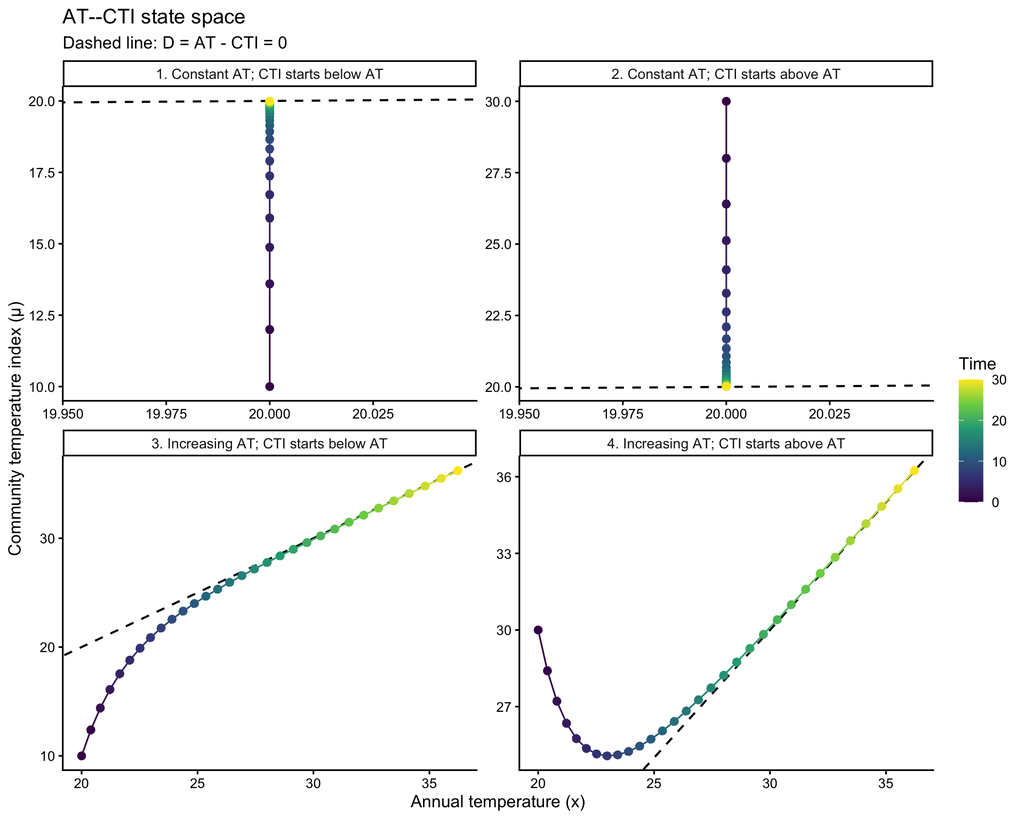

```r
plots_all <- plot_at_cti_dynamics(sim_all, facet = TRUE)
plots_all$space
```

Interpretation:

- The dashed 1:1 line represents $D=0$.
- Cases 1 and 3 begin below the line because $x_0>\mu_0$, so $D_0>0$.
- Cases 2 and 4 begin above the line because $x_0<\mu_0$, so $D_0<0$.
- Under $c=a-b$ and $-1<b<0$, all trajectories approach the 1:1 line without overshooting.
- When $a=0.02$, the target itself moves because AT increases through time.

## 2.2 Time–value trajectories

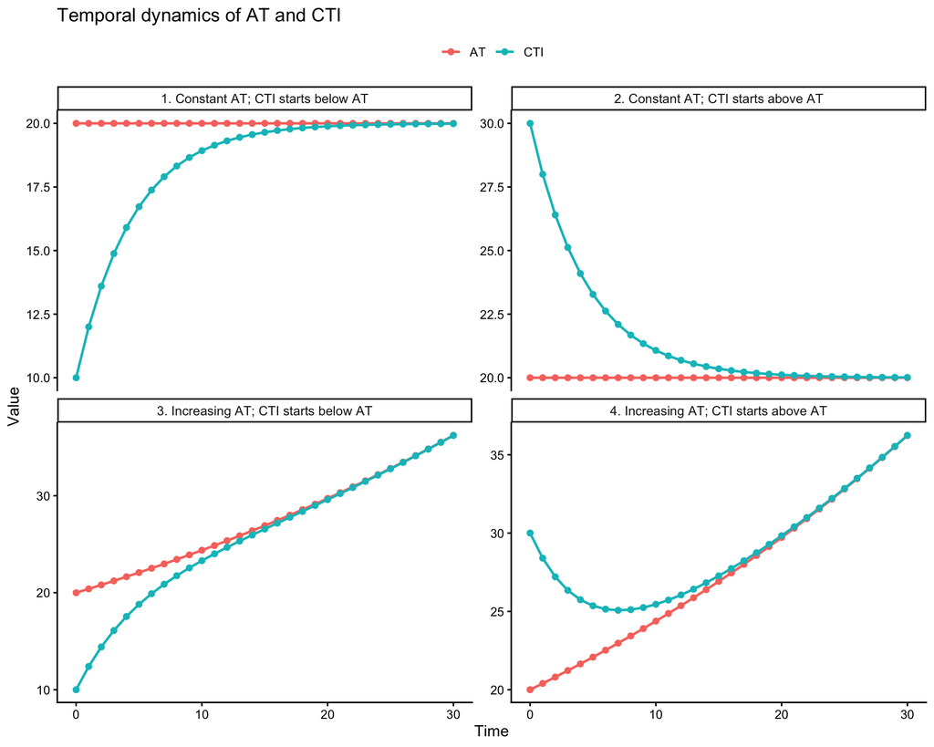

```r
plots_all$time_value
```

## 2.3 Disequilibrium through time

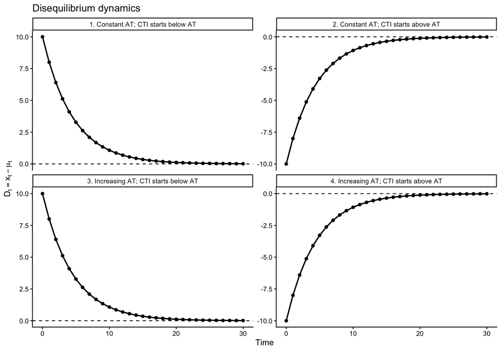

```r
sim_all |>
  ggplot(aes(x = time, y = D)) +
  geom_hline(yintercept = 0, linetype = "dashed") +
  geom_line(linewidth = 0.9) +
  geom_point(size = 1.7) +
  facet_wrap(~case, scales = "free_y") +
  labs(
    x = "Time",
    y = expression(D[t] == x[t] - mu[t]),
    title = "Disequilibrium dynamics"
  )
```

# 3 Estimating the parameters from observations

## 3.1 Model fitting

For empirical data, we can fit the one-way AT–CTI model using linear regression. The two equations are:

$$x_{i,t+1}=\alpha_{x}+\phi_{x}x_{i,t}+\varepsilon^{x}_{i,t},$$

$$\mu_{i,t+1}=\alpha_{\mu}+\phi_{\mu}\mu_{i,t}+cx_{i,t}
+\varepsilon^{\mu}_{i,t}.$$

The dynamic coefficients are still summarized as

$$a=\phi_{x}-1,
\qquad
b=\phi_{\mu}-1.$$

## 3.2 What should be tested?

Three related but distinct questions can be evaluated.

### 3.2.1 Directional AT or disequilibrium effect

$$H_1:c>0.$$

A positive $c$ means that, after accounting for current CTI, a more positive $D_t=x_t-\mu_t$ predicts a higher subsequent CTI.

### 3.2.2 Is $\mu=x$ the invariant target line?

Define

$$q=c-(a-b).$$

Test

$$H_0:q=0.$$

Failure to reject $q=0$ is consistent with $D=0$ being invariant. It does not by itself prove convergence.

Because $a$ is estimated from the AT equation while $b$ and $c$ are estimated from the CTI equation, uncertainty should account for both equations. We could consider using a site-level bootstrap, method to construct the confidence interval for $q$.

### 3.2.3 Does disequilibrium converge?

When $q=0$,

$$D_{t+1}=(1+b)D_t.$$

Convergence requires

$$|1+b|<1.$$

Monotonic convergence without overshooting requires

$$-1<b<0.$$